# Amgen_data

Kalyan Srivastava

4/5/2021

#Importing the data

|  | Subject ID | Time Point | Values | Markers | Treatment Group |
| --- | --- | --- | --- | --- | --- |
| 1 | A | DAY1 | 169 | C4 | TA |
| 2 | A | DAY1 | 207 | C8 | TA |
| 3 | A | DAY1 | 10 | TG | TA |
| 4 | B | DAY1 | 636 | C4 | TA |
| 5 | B | DAY1 | 821 | C8 | TA |
| 6 | B | DAY1 | 19 | TG | TA |
| 7 | F | DAY1 | 254 | C4 | TA |
| 8 | F | DAY1 | 1213 | C8 | TA |
| 9 | F | DAY1 | 6 | TG | TA |
| 10 | L | DAY1 | 90 | C4 | TA |

[output cut: 244 more lines]

```
##     sbj_id          sample_time        digital_count       marker
##  Length:254         Length:254         Min.   :   4.0   Length:254
##  Class :character   Class :character   1st Qu.: 100.5   Class :character
##  Mode  :character   Mode  :character   Median : 292.0   Mode  :character
##                                        Mean   : 569.4
##                                        3rd Qu.: 572.5
##                                        Max.   :6711.0
##   trt_group
##  Length:254
##  Class :character
##  Mode  :character
##
##
##
```

```
## The times point of observations are :     DAY1 DAY15 DAY22 DAY29 DAY8
```

### Please provide a version of this graph with each subject’s digital_count connected by a line, and a unique shape and color for each subject

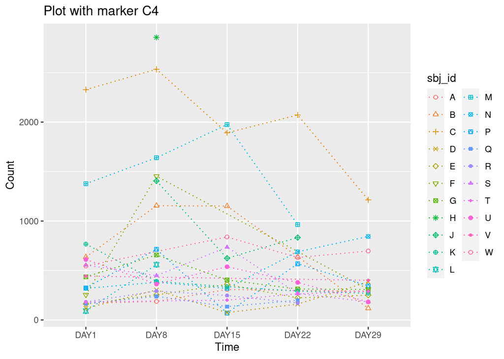

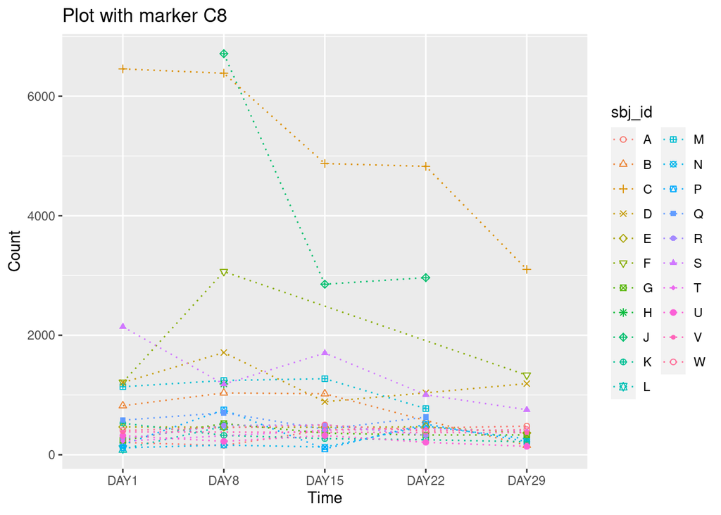

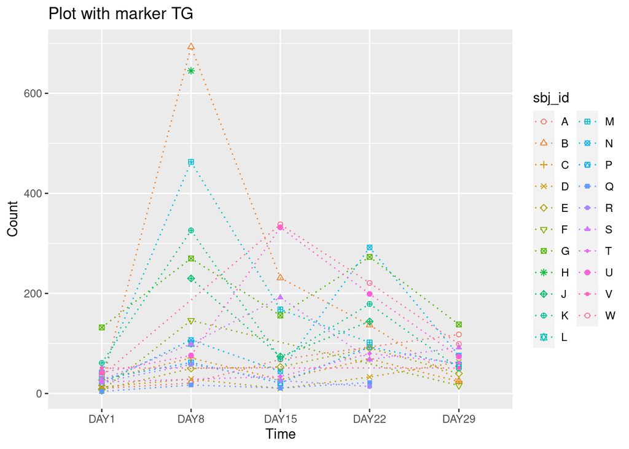

### Please provide a version of this graph as Mean ± SD with each treatment group’s mean connected by a line, and a unique shape and color for each treatment group

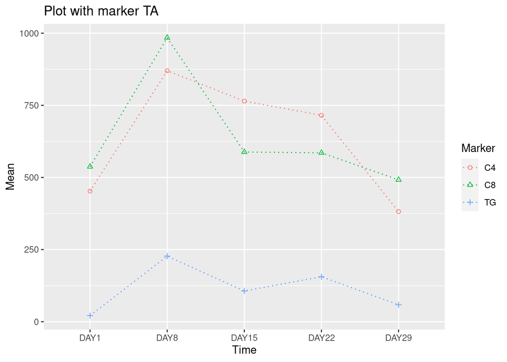

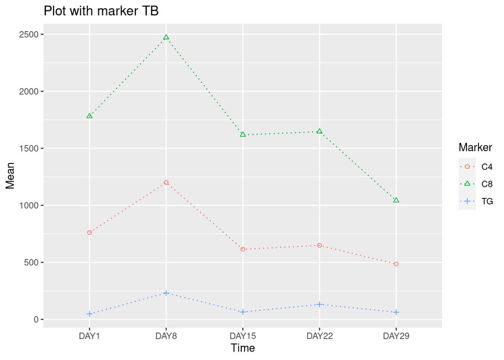

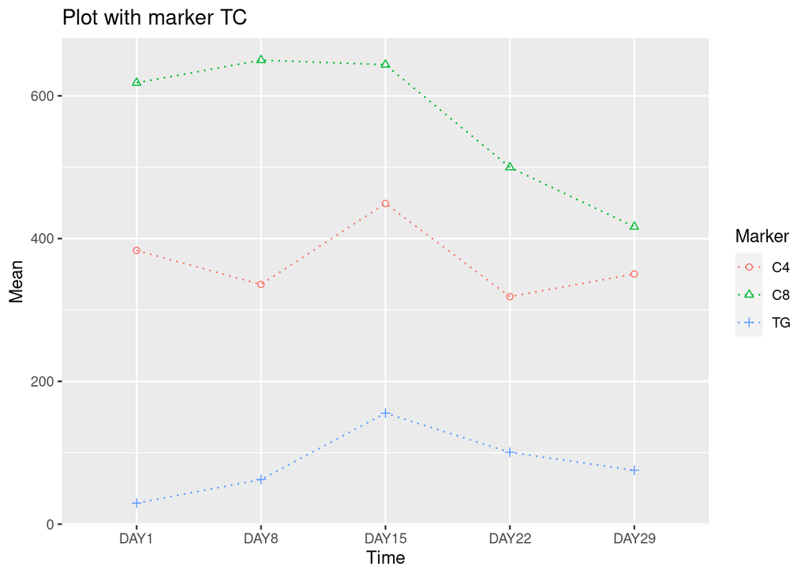

```
## [1] "In theory the above section of code could also be used for SD"
```

### Please convert the input data table to another table in which each sample_time become a separate column filled with corresponding digital counts and other columns remain

|  | sbj_id | marker | trt_group | DAY1 | DAY8 | DAY15 | DAY22 | DAY29 |
| --- | --- | --- | --- | --- | --- | --- | --- | --- |
| 1 | A | C4 | TA | 169 | 187 | 308 |  | 290 |
| 2 | A | C8 | TA | 207 | 156 | 418 |  | 479 |
| 3 | A | TG | TA | 10 | 21 | 68 |  | 118 |
| 4 | B | C4 | TA | 636 | 1155 | 1151 | 640 | 118 |
| 5 | B | C8 | TA | 821 | 1035 | 1021 | 574 | 159 |
| 6 | B | TG | TA | 19 | 693 | 231 | 137 | 25 |
| 7 | C | C4 | TB | 2328 | 2534 | 1892 | 2072 | 1214 |
| 8 | C | C8 | TB | 6456 | 6384 | 4873 | 4826 | 3102 |
| 9 | C | TG | TB | 27 | 71 | 28 | 69 | 24 |
| 10 | D | C4 | TB | 117 | 304 | 74 | 160 | 385 |

[output cut: 53 more lines]

### Please test for each marker whether Day 8 and Day 1 differs at alpha = 0.05 under each treatment

```
## The p value for marker C4 is:     0.1113102
```

```
## The p value for marker C8 is:     0.3055361
```

```
## The p value for marker TG is:     0.004952685
```

### Please fit an approriate statistical model for each marker with digital_count as dependent variables, and sample_time and treatment as independent variables (both are conisidered factors). Assume sbj are randomly drawn from a population. With each model, please report the significance of treatment effect and the contrast between Day 22 and Day 8

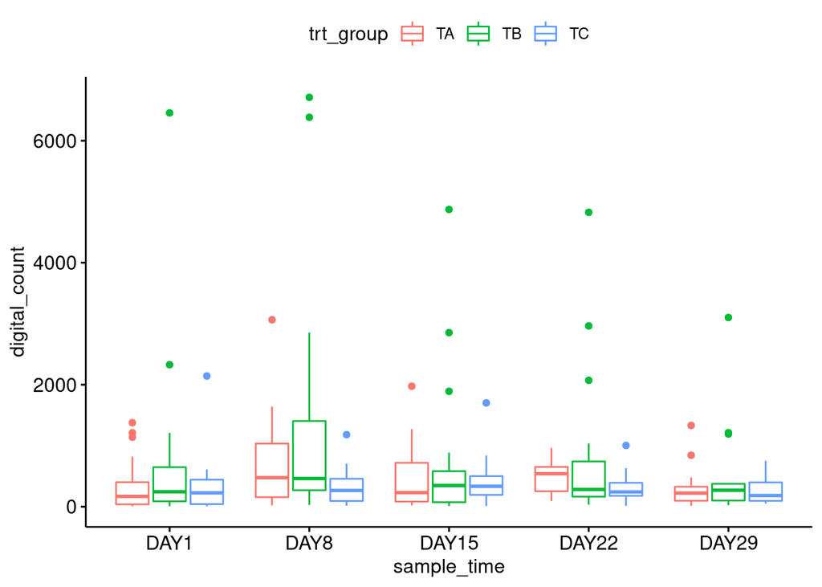

```
##             Df    Sum Sq Mean Sq F value Pr(>F)
## trt_group    2   9920328 4960164   4.231 0.0173 *
## sample_time  1   1813973 1813973   1.547 0.2165
## Residuals   98 114899235 1172441
## ---
## Signif. codes:  0 '***' 0.001 '**' 0.01 '*' 0.05 '.' 0.1 ' ' 1
```

### If you had to analyze 1 million markers, how would you parallelize the tests from question 4 on a multi-processor machine? Please demonstrate this parallelization method using just the markers available in the spreadsheet

```
## [1] "without parallelizing"
```

```
##
##  Welch Two Sample t-test
##
## data:  xA and xB
## t = -1.6416, df = 29.465, p-value = 0.1113
## alternative hypothesis: true difference in means is not equal to 0
## 95 percent confidence interval:
##  -832.98201   90.91768
## sample estimates:
## mean of x mean of y
##  508.5789  879.6111
##
##
##  Welch Two Sample t-test
##
## data:  xA and xB
## t = -1.0418, df = 31.106, p-value = 0.3055
## alternative hypothesis: true difference in means is not equal to 0
## 95 percent confidence interval:
##  -1756.2922   568.5729
## sample estimates:
## mean of x mean of y
##  894.4737 1488.3333
##
##
##  Welch Two Sample t-test
##
## data:  xA and xB
## t = -3.2091, df = 17.671, p-value = 0.004953
## alternative hypothesis: true difference in means is not equal to 0
## 95 percent confidence interval:
##  -265.80869  -55.30243
## sample estimates:
## mean of x mean of y
##  31.83333 192.38889
```

```
## [1] "with parallelizing"
```

```
##
##  Welch Two Sample t-test
##
## data:  xA and xB
## t = -1.6416, df = 29.465, p-value = 0.1113
## alternative hypothesis: true difference in means is not equal to 0
## 95 percent confidence interval:
##  -832.98201   90.91768
## sample estimates:
## mean of x mean of y
##  508.5789  879.6111
##
##
##  Welch Two Sample t-test
##
## data:  xA and xB
## t = -1.0418, df = 31.106, p-value = 0.3055
## alternative hypothesis: true difference in means is not equal to 0
## 95 percent confidence interval:
##  -1756.2922   568.5729
## sample estimates:
## mean of x mean of y
##  894.4737 1488.3333
##
##
##  Welch Two Sample t-test
##
## data:  xA and xB
## t = -3.2091, df = 17.671, p-value = 0.004953
## alternative hypothesis: true difference in means is not equal to 0
## 95 percent confidence interval:
##  -265.80869  -55.30243
## sample estimates:
## mean of x mean of y
##  31.83333 192.38889
```

### Please automate the table view for different layouts, i.e., write a function that takes the input data and another parameter indicating a categorical (nominal) variable so that the output of this function will produce a new table in which each level of the indicated variable become a separate column filled with corresponding digital_counts and others columns remain. In the data provided for the quiz, except “digital_count”, all other variables are factors

|  | sbj_id | sample_time | trt_group | C4 | C8 | TG |
| --- | --- | --- | --- | --- | --- | --- |
| 1 | A | DAY1 | TA | 169 | 207 | 10 |
| 2 | A | DAY8 | TA | 187 | 156 | 21 |
| 3 | A | DAY15 | TA | 308 | 418 | 68 |
| 4 | A | DAY29 | TA | 290 | 479 | 118 |
| 5 | B | DAY1 | TA | 636 | 821 | 19 |
| 6 | B | DAY8 | TA | 1155 | 1035 | 693 |
| 7 | B | DAY15 | TA | 1151 | 1021 | 231 |
| 8 | B | DAY22 | TA | 640 | 574 | 137 |
| 9 | B | DAY29 | TA | 118 | 159 | 25 |
| 10 | C | DAY1 | TB | 2328 | 6456 | 27 |

[output cut: 75 more lines]